# Comparing CRISPRi-mediated suppression of Alzheimer’s disease realated genes in mhCOs treated with Aβ.

Mirco Macchi & Ugne Kisieliute

2022-03-28

- tissue: microglia-induced human cortical organoids (mhCOs) derived from human embryonic stem cells (hESCs) and treated with CRISPRi to suppress AD-associated genes highly expressed in microglia in response to Aβ.
- Platforms Illumina HiSeq 4000
- species: Homo sapiens
- Source: GEO GSE175722

contact: mirco.macchi@studenti.unimi.it; ugne.kisieliute@studenti.unimi.it

###### The goal of the project is to assess the function of Alzheimer’s disease(AD)-associated genes highly expressed in microglia in response to Aβ using pooled CRISPRi.

Load the libraries and the files needed.

```r
{
  library(DESeq2)
  library(ggplot2)
  library(Seurat)
  library(dplyr)
  library(patchwork)
  library(Matrix)
  library(tibble)
}
```

```r
setwd("D:/OneDrive - Politecnico di Milano/PoliMirco/Secondo anno/Primo semestre/Neurogenomics/Exam/microglia-like/")


mhCOcrop <-  ReadMtx(mtx = "CROP-Seq/mhco+ab_crop/GSM5345024_BC04_matrix.mtx.gz",
                 features = "CROP-Seq/mhco+ab_crop/GSM5345024_BC04_features.tsv.gz",
                 cells = "CROP-Seq/mhco+ab_crop/GSM5345024_BC04_barcodes.tsv.gz")


mhCO_b <-  ReadMtx(mtx = "mhCO/mhCO+AB/GSM5345020_mhCOAB_matrix.mtx.gz",
                   features = "mhCO/mhCO+AB/GSM5345020_mhCOAB_features.tsv.gz",
                   cells = "mhCO/mhCO+AB/GSM5345020_mhCOAB_barcodes.tsv.gz")

mhCOcrop <- CreateSeuratObject(counts = mhCOcrop, project = "mhCOcrop",
                           min.cells = 3, min.features = 200)
mhCOcrop
```

```
#> An object of class Seurat
#> 21120 features across 7713 samples within 1 assay
#> Active assay: RNA (21120 features, 0 variable features)
```

```r
mhCO_b <- CreateSeuratObject(counts = mhCO_b, project = "mhCO_b",
                             min.cells = 3, min.features = 200)
mhCO_b
```

```
#> An object of class Seurat
#> 24436 features across 13337 samples within 1 assay
#> Active assay: RNA (24436 features, 0 variable features)
```

Adding metadata

```r
mhCOcrop$type = "CROP-seq+b.amyloid"
mhCO_b$type = "mhCO+b.amyloid"

mhCOCRall <- merge(mhCOcrop, y = mhCO_b, add.cell.ids = c("mhCO+b_Crop", "mhCO_b"), project = "Exam")
head(mhCOCRall)
```

```
#>                                orig.ident nCount_RNA nFeature_RNA
#> mhCO+b_Crop_AAACCCAAGGTTCAGG-1   mhCOcrop      10161         3262
#> mhCO+b_Crop_AAACCCAAGTCACTGT-1   mhCOcrop       6596         2549
#> mhCO+b_Crop_AAACCCACAGCACCCA-1   mhCOcrop       8848         2765
#> mhCO+b_Crop_AAACCCACAGGCGTTC-1   mhCOcrop       4313         2016
#> mhCO+b_Crop_AAACCCACATCGAAGG-1   mhCOcrop       5041         2505
#> mhCO+b_Crop_AAACCCACATTAGGCT-1   mhCOcrop       9821         3079
#> mhCO+b_Crop_AAACCCAGTCGTGATT-1   mhCOcrop       2127         1201
#> mhCO+b_Crop_AAACCCAGTGACACAG-1   mhCOcrop      14345         4367
#> mhCO+b_Crop_AAACCCAGTTAGAAGT-1   mhCOcrop       7667         3117
#> mhCO+b_Crop_AAACCCATCACACCGG-1   mhCOcrop      15891         4248
#>                                              type
#> mhCO+b_Crop_AAACCCAAGGTTCAGG-1 CROP-seq+b.amyloid
#> mhCO+b_Crop_AAACCCAAGTCACTGT-1 CROP-seq+b.amyloid
#> mhCO+b_Crop_AAACCCACAGCACCCA-1 CROP-seq+b.amyloid
#> mhCO+b_Crop_AAACCCACAGGCGTTC-1 CROP-seq+b.amyloid
#> mhCO+b_Crop_AAACCCACATCGAAGG-1 CROP-seq+b.amyloid
#> mhCO+b_Crop_AAACCCACATTAGGCT-1 CROP-seq+b.amyloid
#> mhCO+b_Crop_AAACCCAGTCGTGATT-1 CROP-seq+b.amyloid
#> mhCO+b_Crop_AAACCCAGTGACACAG-1 CROP-seq+b.amyloid
#> mhCO+b_Crop_AAACCCAGTTAGAAGT-1 CROP-seq+b.amyloid
#> mhCO+b_Crop_AAACCCATCACACCGG-1 CROP-seq+b.amyloid
```

```r
tail(mhCOCRall)
```

```
#>                           orig.ident nCount_RNA nFeature_RNA           type
#> mhCO_b_TTTGTTGCATCATGAC-1     mhCO_b       3263         1960 mhCO+b.amyloid
#> mhCO_b_TTTGTTGGTAGTATAG-1     mhCO_b       4905         2395 mhCO+b.amyloid
#> mhCO_b_TTTGTTGGTCGTGGTC-1     mhCO_b       8169         3287 mhCO+b.amyloid
#> mhCO_b_TTTGTTGGTGGACTGA-1     mhCO_b       1215          636 mhCO+b.amyloid
#> mhCO_b_TTTGTTGGTGGGACAT-1     mhCO_b       3225         2012 mhCO+b.amyloid
#> mhCO_b_TTTGTTGGTTAGCTAC-1     mhCO_b       4301         2412 mhCO+b.amyloid
#> mhCO_b_TTTGTTGGTTCGGTAT-1     mhCO_b       4698         2374 mhCO+b.amyloid
#> mhCO_b_TTTGTTGTCCATATGG-1     mhCO_b       3118         1160 mhCO+b.amyloid
#> mhCO_b_TTTGTTGTCGTCTCAC-1     mhCO_b      13930         3929 mhCO+b.amyloid
#> mhCO_b_TTTGTTGTCTCATAGG-1     mhCO_b       5003         2542 mhCO+b.amyloid
```

remove all objects that will not be used.

```r
as.data.frame(mhCOCRall@assays$RNA@counts[1:10, 1:2])
```

```
#>               mhCO+b_Crop_AAACCCAAGGTTCAGG-1 mhCO+b_Crop_AAACCCAAGTCACTGT-1
#> RP11-34P13.7                               0                              0
#> AL627309.1                                 0                              0
#> AP006222.2                                 0                              0
#> RP4-669L17.10                              0                              0
#> RP5-857K21.4                               0                              0
#> RP11-206L10.3                              0                              0
#> RP11-206L10.5                              0                              0
#> RP11-206L10.2                              0                              0
#> RP11-206L10.9                              0                              0
#> FAM87B                                     0                              0
```

Adding a tag containing information about MT and ribosomal genes

```r
mhCOCRall <- PercentageFeatureSet(mhCOCRall, "^MT-", col.name = "percent_mito")
mhCOCRall <- PercentageFeatureSet(mhCOCRall, "^RP[SL]", col.name = "percent_ribo")
head(mhCOCRall)
```

```
#>                                orig.ident nCount_RNA nFeature_RNA
#> mhCO+b_Crop_AAACCCAAGGTTCAGG-1   mhCOcrop      10161         3262
#> mhCO+b_Crop_AAACCCAAGTCACTGT-1   mhCOcrop       6596         2549
#> mhCO+b_Crop_AAACCCACAGCACCCA-1   mhCOcrop       8848         2765
#> mhCO+b_Crop_AAACCCACAGGCGTTC-1   mhCOcrop       4313         2016
#> mhCO+b_Crop_AAACCCACATCGAAGG-1   mhCOcrop       5041         2505
#> mhCO+b_Crop_AAACCCACATTAGGCT-1   mhCOcrop       9821         3079
#> mhCO+b_Crop_AAACCCAGTCGTGATT-1   mhCOcrop       2127         1201
#> mhCO+b_Crop_AAACCCAGTGACACAG-1   mhCOcrop      14345         4367
#> mhCO+b_Crop_AAACCCAGTTAGAAGT-1   mhCOcrop       7667         3117
#> mhCO+b_Crop_AAACCCATCACACCGG-1   mhCOcrop      15891         4248
#>                                              type percent_mito percent_ribo
#> mhCO+b_Crop_AAACCCAAGGTTCAGG-1 CROP-seq+b.amyloid     2.775317    19.397697
#> mhCO+b_Crop_AAACCCAAGTCACTGT-1 CROP-seq+b.amyloid     3.759854    16.297756
#> mhCO+b_Crop_AAACCCACAGCACCCA-1 CROP-seq+b.amyloid     5.187613    16.082731
#> mhCO+b_Crop_AAACCCACAGGCGTTC-1 CROP-seq+b.amyloid     3.570601     9.645259
#> mhCO+b_Crop_AAACCCACATCGAAGG-1 CROP-seq+b.amyloid     3.134299     7.260464
#> mhCO+b_Crop_AAACCCACATTAGGCT-1 CROP-seq+b.amyloid     7.158131    15.568679
#> mhCO+b_Crop_AAACCCAGTCGTGATT-1 CROP-seq+b.amyloid     1.410437    12.035731
#> mhCO+b_Crop_AAACCCAGTGACACAG-1 CROP-seq+b.amyloid     5.060997    14.304636
#> mhCO+b_Crop_AAACCCAGTTAGAAGT-1 CROP-seq+b.amyloid     4.943263    12.521195
#> mhCO+b_Crop_AAACCCATCACACCGG-1 CROP-seq+b.amyloid     6.255113    21.200680
```

```r
ribo_genes <- rownames(mhCOCRall)[grep("^RP[SL]", rownames(mhCOCRall))]
head(ribo_genes, 10)
```

```
#>  [1] "RPL22"   "RPL11"   "RPS6KA1" "RPS8"    "RPL5"    "RPS27"   "RPS10P7"
#>  [8] "RPS6KC1" "RPS7"    "RPS27A"
```

# Quality Control

## QC - I

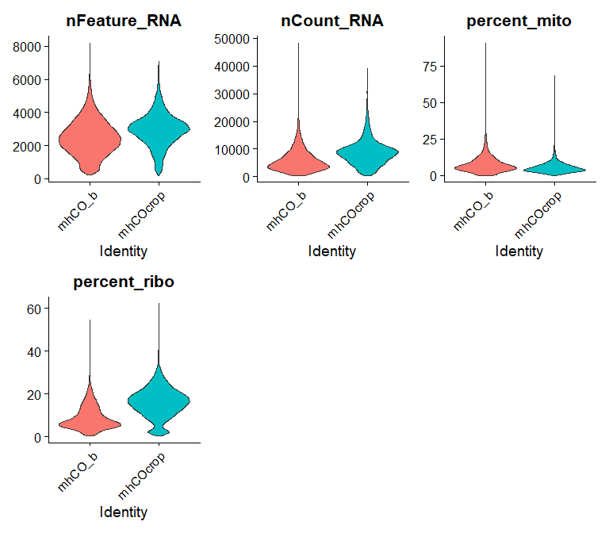

```r
feats <- c("nFeature_RNA", "nCount_RNA", "percent_mito", "percent_ribo")
VlnPlot(mhCOCRall, group.by = "orig.ident", features = feats, pt.size = 0, ncol = 3) +
  NoLegend()
```

The number of features (nrow) and cells (ncol).

```r
dim(mhCOCRall)
```

```
#> [1] 24882 21050
```

numer of cells/sample

```r
table(mhCOCRall$orig.ident)
```

```
#>
#>   mhCO_b mhCOcrop
#>    13337     7713
```

Additionally, we can also see which genes contribute the most to such reads. We can for instance plot the percentage of counts per gene.

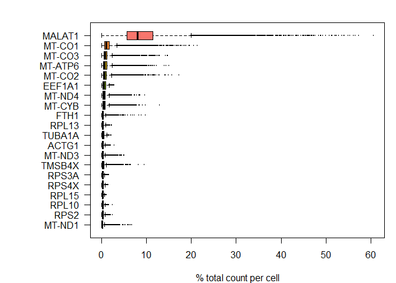

```r
par(mar = c(4, 8, 2, 1))
C <- mhCOCRall@assays$RNA@counts
C <- Matrix::t(Matrix::t(C)/Matrix::colSums(C)) * 100
most_expressed <- order(apply(C, 1, median), decreasing = T)[20:1]
boxplot(as.matrix(t(C[most_expressed, ])), cex = 0.1, las = 1, xlab = "% total count per cell",
        col = (scales::hue_pal())(20)[20:1], horizontal = TRUE)
```

```r
mhCOCRall <- subset(mhCOCRall, subset = nFeature_RNA > 200 & nFeature_RNA < 7500 &
                      percent_mito < 30 & nCount_RNA < 35000 & percent_ribo > 0.025)
```

```r
dim(mhCOCRall)
```

```
#> [1] 24882 20721
```

```r
table(mhCOCRall$orig.ident)
```

```
#>
#>   mhCO_b mhCOcrop
#>    13055     7666
```

## QC - II

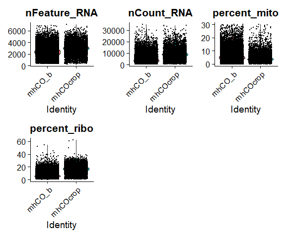

```r
feats <- c("nFeature_RNA", "nCount_RNA", "percent_mito", "percent_ribo")
VlnPlot(mhCOCRall, group.by = "orig.ident", features = feats, pt.size = 0.1, ncol = 3) +
  NoLegend()
```

```r
dim(mhCOCRall)
```

```
#> [1] 24882 20721
```

Filter MALAT1

```r
mhCOCRall <- mhCOCRall[!grepl("MALAT1", rownames(mhCOCRall)), ]
```

Filter Mitocondrial mhCOCRall <- mhCOCRall[!grepl(“^MT-”, rownames(mhCOCRall)), ]

Filter Ribosomal gene mhCOCRall <- mhCOCRall[ ! grepl(‘^RP[SL]’, rownames(mhCOCRall)), ]

```r
dim(mhCOCRall)
```

```
#> [1] 24881 20721
```

# - Data splitting:

split the dataset in two different seurat objects which can be recalled thanks to their original identifier

```r
mhCO.split <- SplitObject(mhCOCRall, split.by = "orig.ident")
```

normalize and identify variable features for each dataset independently

```r
mhCO.split <- lapply(X = mhCO.split, FUN = function(x) {
  x <- NormalizeData(x)
  x <- FindVariableFeatures(x, selection.method = "vst", nfeatures = 2500)
})
```

select features that are repeatedly variable across datasets for integration

```r
features <- SelectIntegrationFeatures(object.list = mhCO.split)
```

# - Calculate cell-cycle scores

```r
mhCOCRall <- CellCycleScoring(object = mhCOCRall, g2m.features = cc.genes$g2m.genes,
                              s.features = cc.genes$s.genes)
```

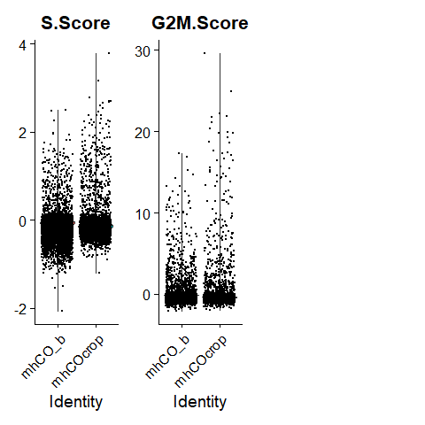

```r
VlnPlot(mhCOCRall, features = c("S.Score", "G2M.Score"), group.by = "orig.ident",
        ncol = 4, pt.size = 0.1)
```

In this case it looks like we only have a few cycling cells in the datasets

# - Perform integration

We then identify anchors using the FindIntegrationAnchors() function, which takes a list of Seurat objects as input, and use these anchors to integrate the datasets together with IntegrateData().

```r
mhCO.anchors <- FindIntegrationAnchors(object.list = mhCO.split, anchor.features = features)
```

```
#> Scaling features for provided objects
#> Finding all pairwise anchors
#> Running CCA
#> Merging objects
#> Finding neighborhoods
#> Finding anchors
#>  Found 20141 anchors
#> Filtering anchors
#>  Retained 2363 anchors
```

this command creates an ‘integrated’ data assay

```r
mhCO.combined <- IntegrateData(anchorset = mhCO.anchors)
```

```
#> Merging dataset 1 into 2
#> Extracting anchors for merged samples
#> Finding integration vectors
#> Finding integration vector weights
#> Integrating data
```

```r
rm(mhCO.anchors, mhCOCRall, C, mhCO.split)
```

## - Perform an integrated analysis

Now we can run a single integrated analysis on all cells. specify that we will perform downstream analysis on the integrated data:

```r
DefaultAssay(mhCO.combined) <- "integrated"
```

## Run the standard workflow for visualization and clustering

```r
mhCO.combined <- ScaleData(mhCO.combined, verbose = FALSE)
mhCO.combined <- RunPCA(mhCO.combined, npcs = 30, verbose = FALSE)
mhCO.combined[["pca"]] #' MOST VARIABLE FREATURES
```

```
#> A dimensional reduction object with key PC_
#>  Number of dimensions: 30
#>  Projected dimensional reduction calculated:  FALSE
#>  Jackstraw run: FALSE
#>  Computed using assay: integrated
```

```r
print(mhCO.combined[["pca"]], dims = 1:5, nfeatures = 5)
```

```
#> PC_ 1
#> Positive:  STMN2, DCX, INA, GRIA2, RTN1
#> Negative:  SPARC, B2M, IFITM3, ZFP36L1, ANXA5
#> PC_ 2
#> Positive:  TOP2A, MKI67, NUF2, CASC5, NUSAP1
#> Negative:  S100A11, DCN, COL1A1, COL3A1, IGF2
#> PC_ 3
#> Positive:  NTRK2, PTN, SPARCL1, CLU, GPM6B
#> Negative:  TSPAN8, CLDN7, EPCAM, RAB25, SERPINA1
#> PC_ 4
#> Positive:  COL3A1, DCN, COL1A1, COL15A1, LUM
#> Negative:  TSPAN8, CLDN7, SERPINA1, FABP1, EPCAM
#> PC_ 5
#> Positive:  TRPM3, HTR2C, FOLR1, TTR, CA2
#> Negative:  PTPRZ1, EDNRB, PTN, GPM6B, C1orf61
```

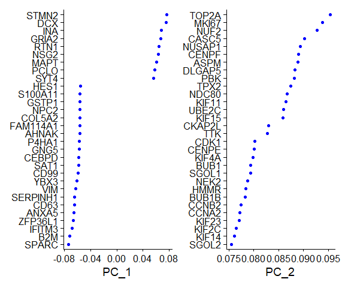

```r
VizDimLoadings(mhCO.combined, dims = 1:2, reduction = "pca")
```

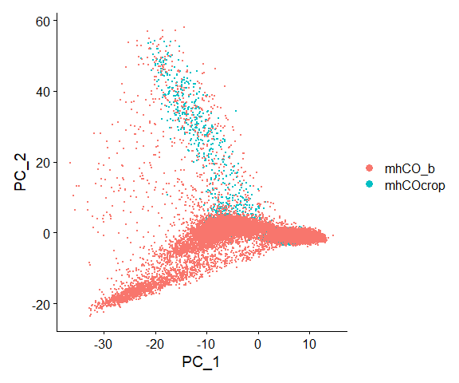

```r
DimPlot(mhCO.combined, reduction = "pca")
```

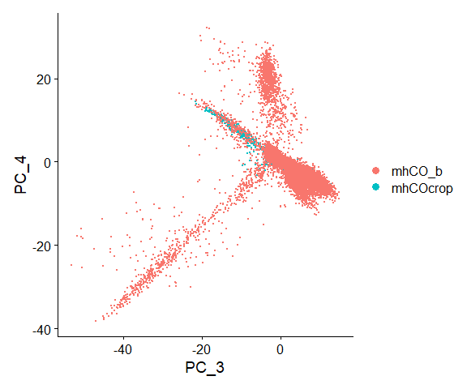

```r
DimPlot(mhCO.combined, reduction = "pca", dims = c(3,4))
```

Plotting heatmaps for each PC:

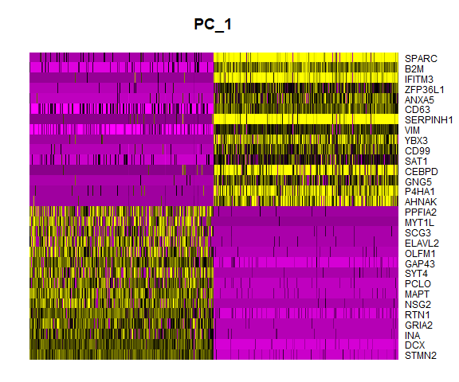

```r
DimHeatmap(mhCO.combined, dims = 1, cells = 500, balanced = TRUE)
```

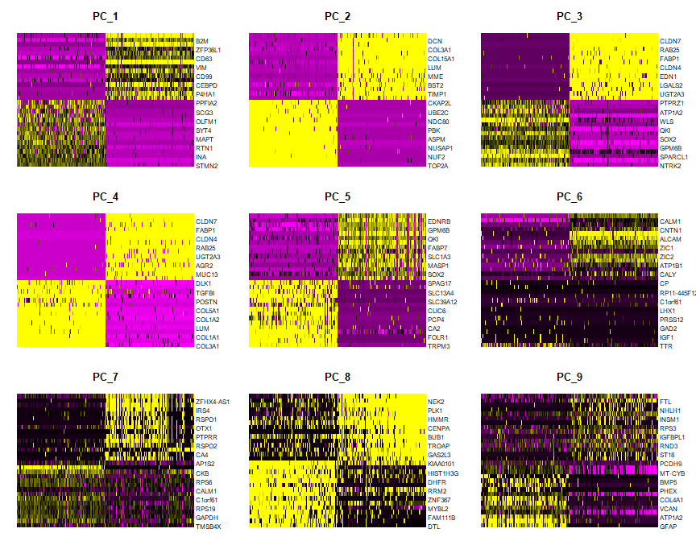

```r
DimHeatmap(mhCO.combined, dims = 1:9, cells = 500, balanced = TRUE)
```

Elbow plot in an informative tool to get optimal trade-off to identify the majority of variation, avoiding overfitting.

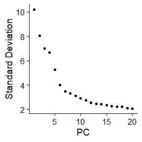

```r
ElbowPlot(mhCO.combined)
```

```r
mhCO.combined <- FindNeighbors(mhCO.combined, reduction = "pca", dims = 1:10)
mhCO.combined <- FindClusters(mhCO.combined, resolution = 0.4)
```

```
#> Modularity Optimizer version 1.3.0 by Ludo Waltman and Nees Jan van Eck
#>
#> Number of nodes: 20721
#> Number of edges: 682936
#>
#> Running Louvain algorithm...
#> Maximum modularity in 10 random starts: 0.9201
#> Number of communities: 15
#> Elapsed time: 3 seconds
```

Get the number of cells contained in each cluster.

```r
summary(mhCO.combined@meta.data$seurat_clusters)
```

```
#>    0    1    2    3    4    5    6    7    8    9   10   11   12   13   14
#> 3559 3135 2893 2347 1452 1365 1269 1252 1134  748  507  352  341  297   70
```

Finally run UMAP.

```r
mhCO.combined <- RunUMAP(mhCO.combined, reduction = "pca", dims = 1:30)
```

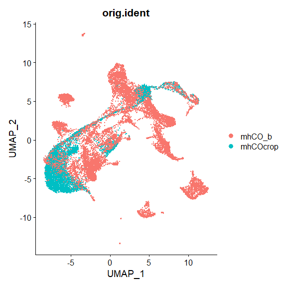

```r
p1 <- DimPlot(mhCO.combined, reduction = "umap", group.by = "orig.ident")
p1
```

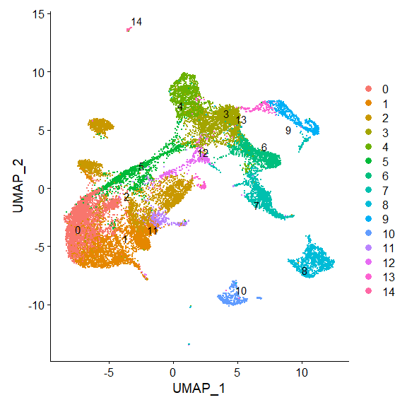

```r
p2 <- DimPlot(mhCO.combined, reduction = "umap", label = TRUE, repel = TRUE)
p2
```

To visualize the two conditions side-by-side, we can use the split.by argument to show each condition colored by cluster.

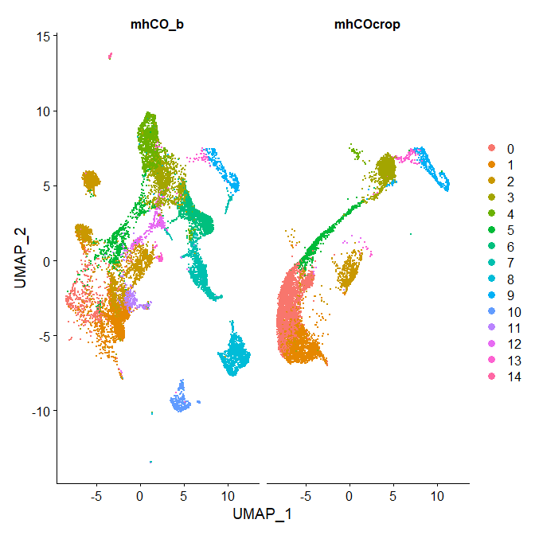

```r
DimPlot(mhCO.combined, reduction = "umap", split.by = "orig.ident")
```

It is clear, that some cluster are not present in CRISPRi sample, meaning that some cells probably have not even undergone differentiation into mature cells or died before the library preparation.

For performing differential expression after integration, we switch back to the original data

```r
DefaultAssay(mhCO.combined) <- "RNA"
```

We can explore these marker genes for each cluster and use them to annotate our clusters as specific cell types.

Cortical Neurons(CN), Interneurons(IN) and Neurons

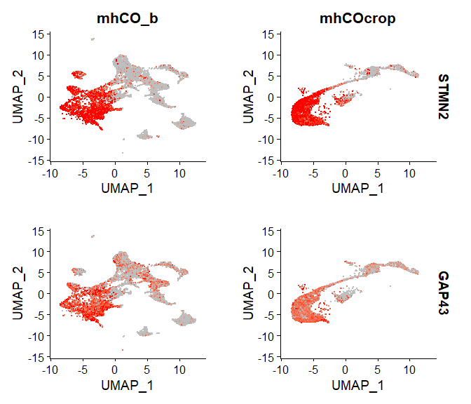

```r
FeaturePlot(mhCO.combined, features = c("STMN2", "GAP43"), split.by = "orig.ident", max.cutoff = 3,
           cols = c("grey", "red"))
```

Neuron progenitor cells(NPC)

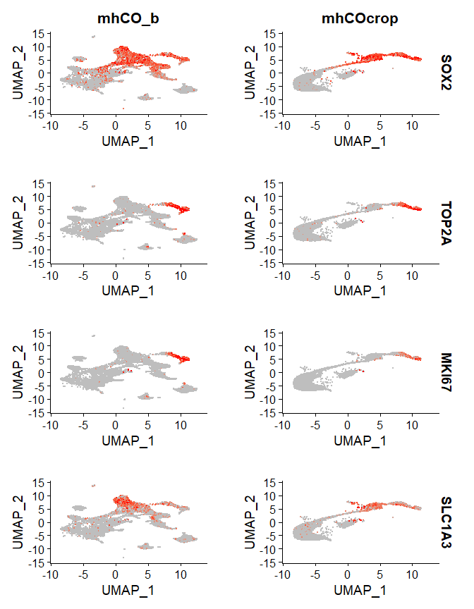

```r
FeaturePlot(mhCO.combined, features = c("SOX2", "TOP2A", "MKI67", "SLC1A3"), split.by = "orig.ident", max.cutoff = 3,cols = c("grey", "red"))
```

Astrocytes(AS)

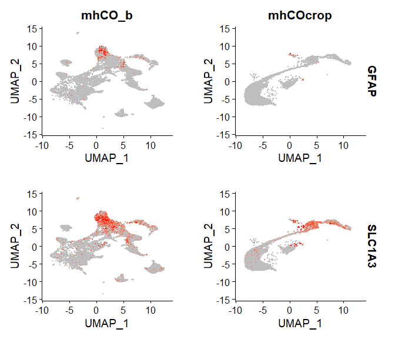

```r
FeaturePlot(mhCO.combined, features = c("GFAP", "SLC1A3"), split.by = "orig.ident", max.cutoff = 3,
             cols = c("grey", "red"))
```

Glia progenitor cells(GPC)/ BMP responsible cell(BRC)

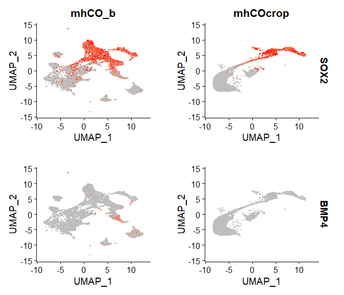

```r
FeaturePlot(mhCO.combined, features = c("SOX2","BMP4"), split.by = "orig.ident", max.cutoff = 3,
             cols = c("grey", "red"))
```

Microglia progenitors cluster A1(MGPA1)

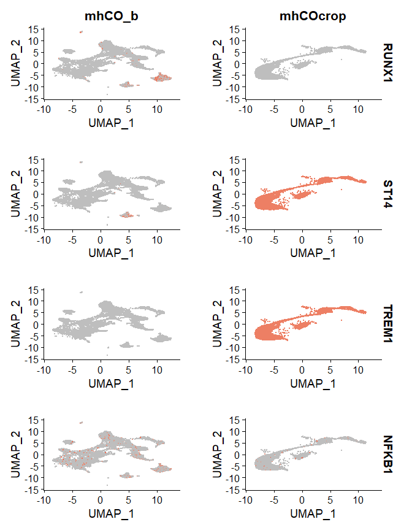

```r
FeaturePlot(mhCO.combined, features = c("RUNX1", "ST14", "TREM1", "NFKB1"), split.by = "orig.ident", max.cutoff = 3,
             cols = c("grey", "red"))
```

# Labelling clusters

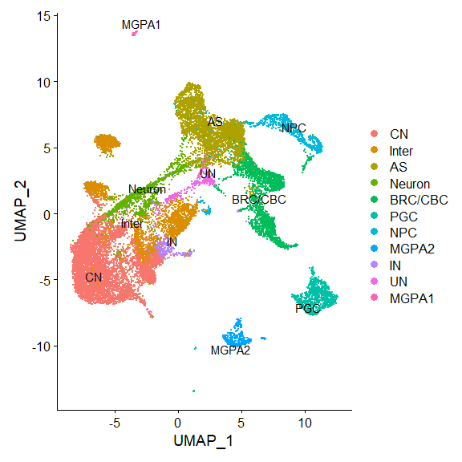

```r
mhCO.combined <- RenameIdents(mhCO.combined, "0"="CN", "1"="CN", "2"= "Inter", "3"="AS", "4"="AS",
                                     "5"="Neuron", "6"="BRC/CBC", "7" = "BRC/CBC", "8"="PGC", "9"="NPC",         "10"="MGPA2","11"= "IN", "12"="UN", "13"= "NPC", "14"="MGPA1")

DimPlot(mhCO.combined, reduction = "umap", label = TRUE, repel = TRUE)
```

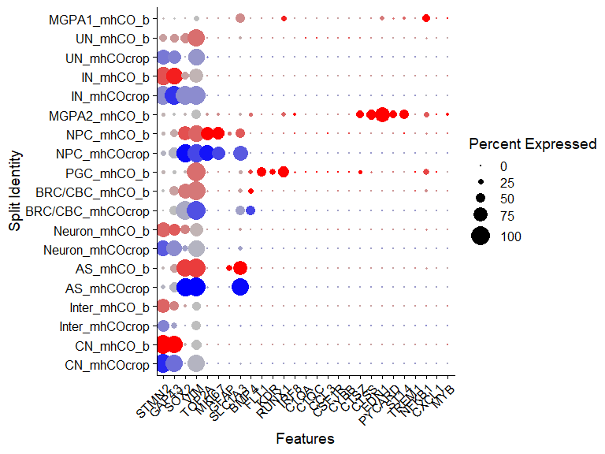

```r
markers.to.plot <- c("STMN2","GAP43","SOX2","VIM","TOP2A","MKI67","GFAP","SLC1A3",
                     "BMP4","FOJ1","FLT1","KDR","RUNX1","IRF8","C1QA","C1QC","CCL3"
                     ,"CSF1R","CYBB","CTSZ","CTSS","EDN1","PYCARD","ST14","TREM1",
                     "NFKB1","CXCL1","MYB")

DotPlot(mhCO.combined, features = markers.to.plot, cols = c("blue", "red"), dot.scale = 8, split.by = "orig.ident") +
  RotatedAxis()
```

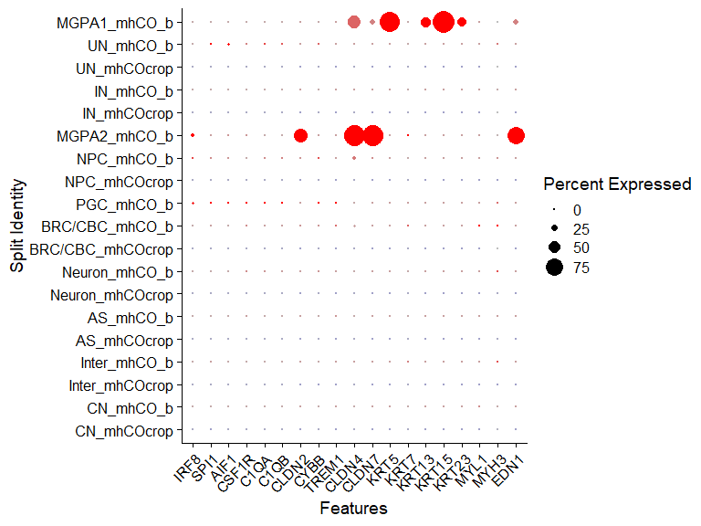

```r
mg.markers<- c("IRF8","SPI1",'AIF1', 'CSF1R', 'C1QA', 'C1QB', 'CLDN2','CYBB','TREM1',
'CLDN4','CLDN7','KRT5','KRT7','KRT13', 'KRT15',"KRT23", "MYL1","MYH3","EDN1")

DotPlot(mhCO.combined, features = mg.markers, cols = c("blue", "red"), dot.scale = 8, split.by = "orig.ident") +
  RotatedAxis()
```

# Gene markers extraction

Since we don’t have microglia in both our datasets, our best option is to find all markers. With this function we are comparing each cluster against all other clusters to identify potential marker genes. The cells in each cluster are treated as replicates, and essentially a differential expression analysis is performed with some statistical test.

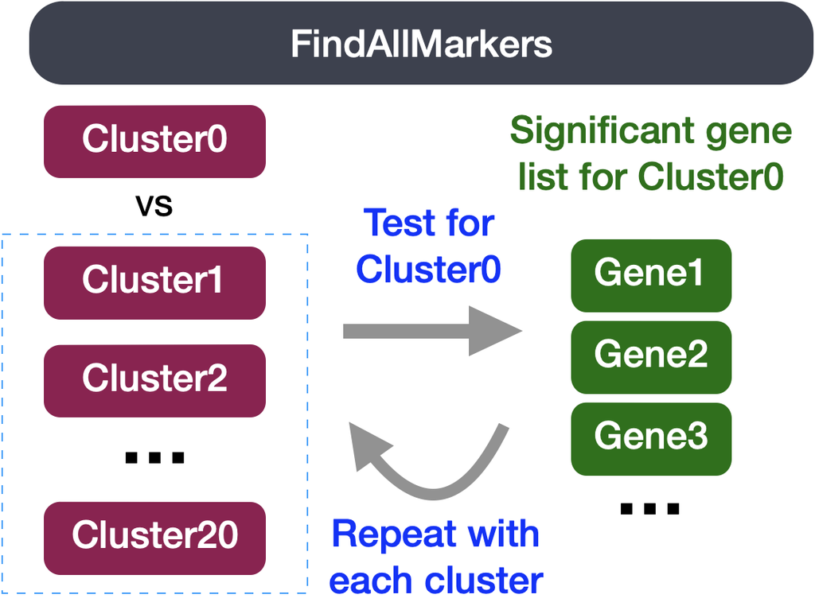

FindConserverdMarkers function

This line gets all markers regardless of the sample they come from

```r
CropALL.mark <- FindAllMarkers(mhCO.combined, only.pos = TRUE, test.use = 't',
                           min.pct = 0.25, min.diff.pct = 0.5, logfc.threshold = 1.25)
```

```
#> Warning in FindMarkers.default(object = data.use, slot = data.slot, counts =
#> counts, : No features pass logfc.threshold threshold; returning empty data.frame
#> Warning in FindMarkers.default(object = data.use, slot = data.slot, counts =
#> counts, : No features pass min.diff.pct threshold; returning empty data.frame
```

Visualize top markers per cluster

```r
top <- CropALL.mark %>% group_by(cluster) %>% top_n(n = 1, wt = avg_log2FC)
top
```

```
#> # A tibble: 9 x 7
#> # Groups:   cluster [9]
#>       p_val avg_log2FC pct.1 pct.2 p_val_adj cluster gene
#>       <dbl>      <dbl> <dbl> <dbl>     <dbl> <fct>   <chr>
#> 1 0               2.10 0.996 0.359 0         CN      STMN2
#> 2 0               2.13 0.796 0.149 0         AS      SLC1A3
#> 3 4.82e-210       1.47 0.681 0.16  1.20e-205 Neuron  INSM1
#> 4 0               2.56 0.645 0.099 0         BRC/CBC TRPM3
#> 5 0               6.75 0.979 0.149 0         PGC     COL3A1
#> 6 2.21e-230       3.67 0.792 0.089 5.50e-226 NPC     CENPF
#> 7 1.26e- 93       4.36 0.706 0.009 3.15e- 89 MGPA2   RBP2
#> 8 9.57e- 87       2.22 0.868 0.31  2.38e- 82 UN      DDIT3
#> 9 1.34e- 37       4.30 0.971 0.003 3.34e- 33 MGPA1   KRT15
```

EDN1 - inflammatory gene.

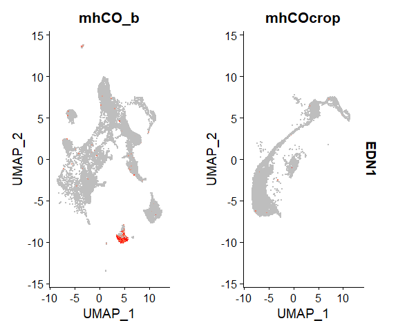

```r
FeaturePlot(mhCO.combined, features = c("EDN1"), split.by = "orig.ident", max.cutoff = 3,
            cols = c("grey", "red"))
```

MG activation genes:

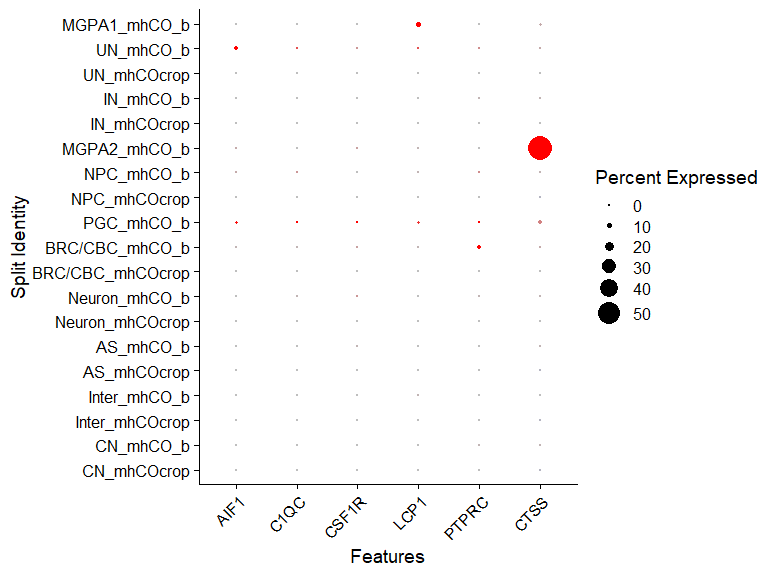

```r
mg.activation.markers <- c("AIF1", "C1QC", "CSF1R", "LCP1", "PTPRC", "CTSS")
DotPlot(mhCO.combined, features = mg.activation.markers, cols = c("blue", "red"), dot.scale = 8, split.by = "orig.ident") +
  RotatedAxis()
```

It looks like we have no microglial activation in CRISPRi sample.

### Phagocytosis markers

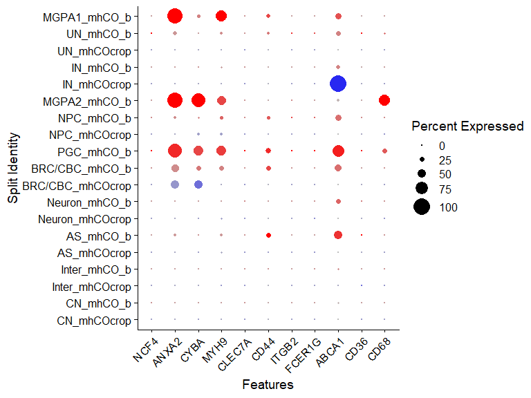

```r
phagocytic.markers <- c("NCF4","ANXA2","CYBA","MYH9","CLEC7A","CD44","ITGB2", "FCER1G","ABCA1","CD36", "CD68")

DotPlot(mhCO.combined, features = phagocytic.markers, cols = c("blue", "red"), dot.scale = 8, split.by = "orig.ident") +
  RotatedAxis()
```

### Ferropotosis mediators markers

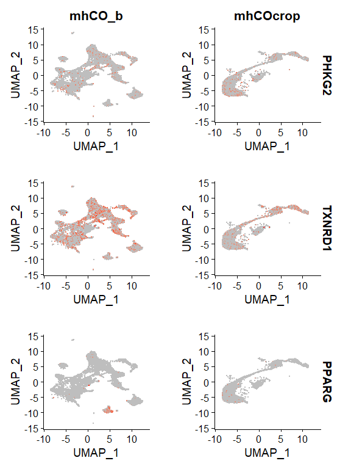

```r
FeaturePlot(mhCO.combined, features = c("PHKG2", "TXNRD1", "PPARG"), split.by = "orig.ident", max.cutoff = 3,
            cols = c("grey", "red"))
```

# Gene ontology analysis

We run GO on Unkown cluster to gather some more insights.

```r
library(GOstats)
library(GO.db)
library(org.Hs.eg.db)
hs <- org.Hs.eg.db
```

```r
GeneUniverse <- read.table("D:/OneDrive - Politecnico di Milano/PoliMirco/Secondo anno/Primo semestre/Neurogenomics/Exam/microglia-like/mhCO/GSM5345019_mhCO_features.tsv", header = FALSE )
GeneUniverse.symbols <- GeneUniverse$V2
Universe_symbol_entrez <- select(hs, keys = GeneUniverse.symbols, columns = c("ENTREZID","SYMBOL"), keytype = "SYMBOL")
Universe.entrezIDs <- Universe_symbol_entrez$ENTREZID
```

```r
UN.mark <- CropALL.mark[CropALL.mark$cluster=='UN',]
UN.symbols <- UN.mark$gene
UN_symbol_entrez <- select(hs, keys = UN.symbols, columns = c("ENTREZID","SYMBOL"), keytype = "SYMBOL")
UN.entrezIDs <- UN_symbol_entrez$ENTREZID
```

```r
upParams = new("GOHyperGParams",geneIds = UN.entrezIDs,universeGeneIds = Universe.entrezIDs,
               annotation="org.Hs.eg.db",ontology="BP",pvalueCutoff=0.01,
               conditional=FALSE, testDirection="over")
upBP = hyperGTest(upParams)

summary(upBP)[1:10,]
```

```
#>        GOBPID       Pvalue OddsRatio     ExpCount Count Size
#> 1  GO:0044324 0.0001235254       Inf 0.0001235254     1    2
#> 2  GO:2000016 0.0001235254       Inf 0.0001235254     1    2
#> 3  GO:1990442 0.0001852881       Inf 0.0001852881     1    3
#> 4  GO:2000015 0.0002470508       Inf 0.0002470508     1    4
#> 5  GO:0032792 0.0003088135       Inf 0.0003088135     1    5
#> 6  GO:0071500 0.0003705762       Inf 0.0003705762     1    6
#> 7  GO:1903026 0.0003705762       Inf 0.0003705762     1    6
#> 8  GO:0032713 0.0004323390       Inf 0.0004323390     1    7
#> 9  GO:0001955 0.0004941017       Inf 0.0004941017     1    8
#> 10 GO:0048263 0.0005558644       Inf 0.0005558644     1    9
#>                                                                                        Term
#> 1             regulation of transcription involved in anterior/posterior axis specification
#> 2                                   negative regulation of determination of dorsal identity
#> 3                   intrinsic apoptotic signaling pathway in response to nitrosative stress
#> 4                                            regulation of determination of dorsal identity
#> 5                                 negative regulation of CREB transcription factor activity
#> 6                                                   cellular response to nitrosative stress
#> 7  negative regulation of RNA polymerase II regulatory region sequence-specific DNA binding
#> 8                                           negative regulation of interleukin-4 production
#> 9                                                                   blood vessel maturation
#> 10                                                         determination of dorsal identity
```

# ssGSEA

```r
library(dittoSeq)
library(escape)
```

Remove metadata that can interfere with computing of Enrichment Score(ES)

```r
mhCO.combined@meta.data$nCount_RNA <- NULL
mhCO.combined@meta.data$nFeature_RNA <- NULL
mhCO.combined@meta.data$percent_mito <- NULL
mhCO.combined@meta.data$percent_ribo <- NULL
mhCO.combined@meta.data$type <- NULL
mhCO.combined@meta.data$integrated_snn_res.0.4 <- NULL
```

## Getting Gene Sets

C2 = curated gene sets; C5 = ontology gene sets

```r
GS.hallmark <- getGeneSets(library = "C2", gene.sets =c("KEGG_ABC_TRANSPORTERS",
                                                        "KEGG_ACUTE_MYELOID_LEUKEMIA",
                                                        "KEGG_ADHERENS_JUNCTION",
                                                        "KEGG_ADIPOCYTOKINE_SIGNALING_PATHWAY",
                                                        "KEGG_ALANINE_ASPARTATE_AND_GLUTAMATE_METABOLISM",
                                                        "KEGG_ALDOSTERONE_REGULATED_SODIUM_REABSORPTION",
                                                        "KEGG_ALLOGRAFT_REJECTION",
                                                        "KEGG_ALPHA_LINOLENIC_ACID_METABOLISM",
                                                        "KEGG_ALZHEIMERS_DISEASE",
                                                        "KEGG_AMINO_SUGAR_AND_NUCLEOTIDE_SUGAR_METABOLISM",
                                                        "KEGG_AMINOACYL_TRNA_BIOSYNTHESIS",
                                                        "KEGG_AMYOTROPHIC_LATERAL_SCLEROSIS_ALS",
                                                        "KEGG_ANTIGEN_PROCESSING_AND_PRESENTATION",
                                                        "KEGG_APOPTOSIS",
                                                        "KEGG_ARACHIDONIC_ACID_METABOLISM",
                                                        "KEGG_ARGININE_AND_PROLINE_METABOLISM",
                                                    "KEGG_ARRHYTHMOGENIC_RIGHT_VENTRICULAR_CARDIOMYOPATHY_ARVC",
                                                        "KEGG_ASCORBATE_AND_ALDARATE_METABOLISM",
                                                        "KEGG_ASTHMA",
                                                        "KEGG_AUTOIMMUNE_THYROID_DISEASE",
                                                        "KEGG_AXON_GUIDANCE",
                                                        "KEGG_B_CELL_RECEPTOR_SIGNALING_PATHWAY",
                                                        "KEGG_BASAL_CELL_CARCINOMA",
                                                        "KEGG_BASAL_TRANSCRIPTION_FACTORS",
                                                        "KEGG_BASE_EXCISION_REPAIR",
                                                        "KEGG_BETA_ALANINE_METABOLISM",
                                                        "KEGG_BIOSYNTHESIS_OF_UNSATURATED_FATTY_ACIDS",
                                                        "KEGG_BLADDER_CANCER",
                                                        "KEGG_BUTANOATE_METABOLISM",
                                                        "KEGG_CALCIUM_SIGNALING_PATHWAY",
                                                        "KEGG_CARDIAC_MUSCLE_CONTRACTION",
                                                        "KEGG_CELL_ADHESION_MOLECULES_CAMS",
                                                        "KEGG_CELL_CYCLE",
                                                        "KEGG_CHEMOKINE_SIGNALING_PATHWAY",
                                                        "KEGG_CHRONIC_MYELOID_LEUKEMIA",
                                                        "KEGG_CIRCADIAN_RHYTHM_MAMMAL",
                                                        "KEGG_CITRATE_CYCLE_TCA_CYCLE",
                                                        "KEGG_COLORECTAL_CANCER",
                                                        "KEGG_COMPLEMENT_AND_COAGULATION_CASCADES",
                                                        "KEGG_CYSTEINE_AND_METHIONINE_METABOLISM",
                                                        "KEGG_CYTOKINE_CYTOKINE_RECEPTOR_INTERACTION",
                                                        "KEGG_CYTOSOLIC_DNA_SENSING_PATHWAY",
                                                        "KEGG_DILATED_CARDIOMYOPATHY",
                                                        "KEGG_DNA_REPLICATION",
                                                        "KEGG_DORSO_VENTRAL_AXIS_FORMATION",
                                                        "KEGG_DRUG_METABOLISM_CYTOCHROME_P450",
                                                        "KEGG_DRUG_METABOLISM_OTHER_ENZYMES",
                                                        "KEGG_ECM_RECEPTOR_INTERACTION",
                                                        "KEGG_ENDOCYTOSIS",
                                                        "KEGG_ENDOMETRIAL_CANCER",
                                              "KEGG_EPITHELIAL_CELL_SIGNALING_IN_HELICOBACTER_PYLORI_INFECTION",
                                                        "KEGG_ERBB_SIGNALING_PATHWAY",
                                                        "KEGG_ETHER_LIPID_METABOLISM",
                                                        "KEGG_FATTY_ACID_METABOLISM",
                                                        "KEGG_FC_EPSILON_RI_SIGNALING_PATHWAY",
                                                        "KEGG_FC_GAMMA_R_MEDIATED_PHAGOCYTOSIS",
                                                        "KEGG_FOCAL_ADHESION",
                                                        "KEGG_FOLATE_BIOSYNTHESIS",
                                                        "KEGG_FRUCTOSE_AND_MANNOSE_METABOLISM",
                                                        "KEGG_GALACTOSE_METABOLISM",
                                                        "KEGG_GAP_JUNCTION",
                                                        "KEGG_GLIOMA",
                                                        "KEGG_GLUTATHIONE_METABOLISM",
                                                        "KEGG_GLYCEROLIPID_METABOLISM",
                                                        "KEGG_GLYCEROPHOSPHOLIPID_METABOLISM",
                                                        "KEGG_GLYCINE_SERINE_AND_THREONINE_METABOLISM",
                                                        "KEGG_GLYCOLYSIS_GLUCONEOGENESIS",
                                                      "KEGG_GLYCOSAMINOGLYCAN_BIOSYNTHESIS_CHONDROITIN_SULFATE",
                                                        "KEGG_GLYCOSAMINOGLYCAN_BIOSYNTHESIS_HEPARAN_SULFATE",
                                                        "KEGG_GLYCOSAMINOGLYCAN_BIOSYNTHESIS_KERATAN_SULFATE",
                                                        "KEGG_GLYCOSAMINOGLYCAN_DEGRADATION",
                                                        "KEGG_GLYCOSPHINGOLIPID_BIOSYNTHESIS_GANGLIO_SERIES",
                                                        "KEGG_GLYCOSPHINGOLIPID_BIOSYNTHESIS_GLOBO_SERIES",
                                              "KEGG_GLYCOSPHINGOLIPID_BIOSYNTHESIS_LACTO_AND_NEOLACTO_SERIES",
                                                  "KEGG_GLYCOSYLPHOSPHATIDYLINOSITOL_GPI_ANCHOR_BIOSYNTHESIS",
                                                        "KEGG_GLYOXYLATE_AND_DICARBOXYLATE_METABOLISM",
                                                        "KEGG_GNRH_SIGNALING_PATHWAY",
                                                        "KEGG_GRAFT_VERSUS_HOST_DISEASE",
                                                        "KEGG_HEDGEHOG_SIGNALING_PATHWAY",
                                                        "KEGG_HEMATOPOIETIC_CELL_LINEAGE",
                                                        "KEGG_HISTIDINE_METABOLISM",
                                                        "KEGG_HOMOLOGOUS_RECOMBINATION",
                                                        "KEGG_HUNTINGTONS_DISEASE",
                                                        "KEGG_HYPERTROPHIC_CARDIOMYOPATHY_HCM",
                                                        "KEGG_INOSITOL_PHOSPHATE_METABOLISM",
                                                        "KEGG_INSULIN_SIGNALING_PATHWAY",
                                                        "KEGG_INTESTINAL_IMMUNE_NETWORK_FOR_IGA_PRODUCTION",
                                                        "KEGG_JAK_STAT_SIGNALING_PATHWAY",
                                                        "KEGG_LEISHMANIA_INFECTION",
                                                        "KEGG_LEUKOCYTE_TRANSENDOTHELIAL_MIGRATION",
                                                        "KEGG_LIMONENE_AND_PINENE_DEGRADATION",
                                                        "KEGG_LINOLEIC_ACID_METABOLISM",
                                                        "KEGG_LONG_TERM_DEPRESSION",
                                                        "KEGG_LONG_TERM_POTENTIATION",
                                                        "KEGG_LYSINE_DEGRADATION",
                                                        "KEGG_LYSOSOME",
                                                        "KEGG_MAPK_SIGNALING_PATHWAY",
                                                        "KEGG_MATURITY_ONSET_DIABETES_OF_THE_YOUNG",
                                                        "KEGG_MELANOGENESIS",
                                                        "KEGG_MELANOMA",
                                                        "KEGG_METABOLISM_OF_XENOBIOTICS_BY_CYTOCHROME_P450",
                                                        "KEGG_MISMATCH_REPAIR",
                                                        "KEGG_MTOR_SIGNALING_PATHWAY",
                                                        "KEGG_N_GLYCAN_BIOSYNTHESIS",
                                                        "KEGG_NATURAL_KILLER_CELL_MEDIATED_CYTOTOXICITY",
                                                        "KEGG_NEUROACTIVE_LIGAND_RECEPTOR_INTERACTION",
                                                        "KEGG_NEUROTROPHIN_SIGNALING_PATHWAY",
                                                        "KEGG_NICOTINATE_AND_NICOTINAMIDE_METABOLISM",
                                                        "KEGG_NITROGEN_METABOLISM",
                                                        "KEGG_NOD_LIKE_RECEPTOR_SIGNALING_PATHWAY",
                                                        "KEGG_NON_HOMOLOGOUS_END_JOINING",
                                                        "KEGG_NON_SMALL_CELL_LUNG_CANCER",
                                                        "KEGG_NOTCH_SIGNALING_PATHWAY",
                                                        "KEGG_NUCLEOTIDE_EXCISION_REPAIR",
                                                        "KEGG_O_GLYCAN_BIOSYNTHESIS",
                                                        "KEGG_OLFACTORY_TRANSDUCTION",
                                                        "KEGG_ONE_CARBON_POOL_BY_FOLATE",
                                                        "KEGG_OOCYTE_MEIOSIS",
                                                        "KEGG_OTHER_GLYCAN_DEGRADATION",
                                                        "KEGG_OXIDATIVE_PHOSPHORYLATION",
                                                        "KEGG_P53_SIGNALING_PATHWAY",
                                                        "KEGG_PANCREATIC_CANCER",
                                                        "KEGG_PANTOTHENATE_AND_COA_BIOSYNTHESIS",
                                                        "KEGG_PARKINSONS_DISEASE",
                                                        "KEGG_PATHOGENIC_ESCHERICHIA_COLI_INFECTION",
                                                        "KEGG_PATHWAYS_IN_CANCER",
                                                        "KEGG_PENTOSE_AND_GLUCURONATE_INTERCONVERSIONS",
                                                        "KEGG_PENTOSE_PHOSPHATE_PATHWAY",
                                                        "KEGG_PEROXISOME",
                                                        "KEGG_PHENYLALANINE_METABOLISM",
                                                        "KEGG_PHOSPHATIDYLINOSITOL_SIGNALING_SYSTEM",
                                                        "KEGG_PORPHYRIN_AND_CHLOROPHYLL_METABOLISM",
```

```r
                                                        "KEGG_PPAR_SIGNALING_PATHWAY",
                                                        "KEGG_PRIMARY_BILE_ACID_BIOSYNTHESIS",
                                                        "KEGG_PRIMARY_IMMUNODEFICIENCY",
                                                        "KEGG_PRION_DISEASES",
                                                        "KEGG_PROGESTERONE_MEDIATED_OOCYTE_MATURATION",
                                                        "KEGG_PROPANOATE_METABOLISM",
                                                        "KEGG_PROSTATE_CANCER",
                                                        "KEGG_PROTEASOME",
                                                        "KEGG_PROTEIN_EXPORT",
                                                        "KEGG_PROXIMAL_TUBULE_BICARBONATE_RECLAMATION",
                                                        "KEGG_PURINE_METABOLISM",
                                                        "KEGG_PYRIMIDINE_METABOLISM",
                                                        "KEGG_PYRUVATE_METABOLISM",
                                                        "KEGG_REGULATION_OF_ACTIN_CYTOSKELETON",
                                                        "KEGG_REGULATION_OF_AUTOPHAGY",
                                                        "KEGG_RENAL_CELL_CARCINOMA",
                                                        "KEGG_RENIN_ANGIOTENSIN_SYSTEM",
                                                        "KEGG_RETINOL_METABOLISM",
                                                        "KEGG_RIBOFLAVIN_METABOLISM",
                                                        "KEGG_RIBOSOME",
                                                        "KEGG_RIG_I_LIKE_RECEPTOR_SIGNALING_PATHWAY",
                                                        "KEGG_RNA_DEGRADATION",
                                                        "KEGG_RNA_POLYMERASE",
                                                        "KEGG_SELENOAMINO_ACID_METABOLISM",
                                                        "KEGG_SMALL_CELL_LUNG_CANCER",
                                                        "KEGG_SNARE_INTERACTIONS_IN_VESICULAR_TRANSPORT",
                                                        "KEGG_SPHINGOLIPID_METABOLISM",
                                                        "KEGG_SPLICEOSOME",
                                                        "KEGG_STARCH_AND_SUCROSE_METABOLISM",
                                                        "KEGG_STEROID_BIOSYNTHESIS",
                                                        "KEGG_STEROID_HORMONE_BIOSYNTHESIS",
                                                        "KEGG_SULFUR_METABOLISM",
                                                        "KEGG_SYSTEMIC_LUPUS_ERYTHEMATOSUS",
                                                        "KEGG_T_CELL_RECEPTOR_SIGNALING_PATHWAY",
                                                        "KEGG_TASTE_TRANSDUCTION",
                                                        "KEGG_TAURINE_AND_HYPOTAURINE_METABOLISM",
                                                        "KEGG_TERPENOID_BACKBONE_BIOSYNTHESIS",
                                                        "KEGG_TGF_BETA_SIGNALING_PATHWAY",
                                                        "KEGG_THYROID_CANCER",
                                                        "KEGG_TIGHT_JUNCTION",
                                                        "KEGG_TOLL_LIKE_RECEPTOR_SIGNALING_PATHWAY",
                                                        "KEGG_TRYPTOPHAN_METABOLISM",
                                                        "KEGG_TYPE_I_DIABETES_MELLITUS",
                                                        "KEGG_TYPE_II_DIABETES_MELLITUS",
                                                        "KEGG_TYROSINE_METABOLISM",
                                                        "KEGG_UBIQUITIN_MEDIATED_PROTEOLYSIS",
                                                        "KEGG_VALINE_LEUCINE_AND_ISOLEUCINE_BIOSYNTHESIS",
                                                        "KEGG_VALINE_LEUCINE_AND_ISOLEUCINE_DEGRADATION",
                                                        "KEGG_VASCULAR_SMOOTH_MUSCLE_CONTRACTION",
                                                        "KEGG_VASOPRESSIN_REGULATED_WATER_REABSORPTION",
                                                        "KEGG_VEGF_SIGNALING_PATHWAY",
                                                        "KEGG_VIBRIO_CHOLERAE_INFECTION",
                                                        "KEGG_VIRAL_MYOCARDITIS",
                                                        "KEGG_WNT_SIGNALING_PATHWAY") )
```

## Enrichment

The next step is performing the enrichment on the RNA count data The function enrichIt() can handle either a matrix of raw count data or will pull that data directly from a Seurat object. The enrichment scores will be calculated across all individual cells

```r
ES.mhCO <- enrichIt(obj = mhCO.combined, gene.sets = GS.hallmark, groups = 1000, cores = 4)
```

[output not shown]

[output cut: 9 more lines]

[output not shown]

We can then easily add these results back to our Seurat object.

```r
mhCO.combined <- Seurat::AddMetaData(mhCO.combined, ES.mhCO)
```

### Visualizations

The easiest way to generate almost any visualization for single cell data is via dittoSeq, which is an extremely flexible visualization package for both bulk and single-cell RNA-seq data that works very well for both expression data and metadata.

To keep things consistent, we’ll define a pleasing color scheme.

```r
colors <- colorRampPalette(c("#0348A6", "#7AC5FF", "#C6FDEC", "#FFB433", "#FF4B20"))
```

Heatmaps A simple way to approach visualizations for enrichment results is the heatmap:

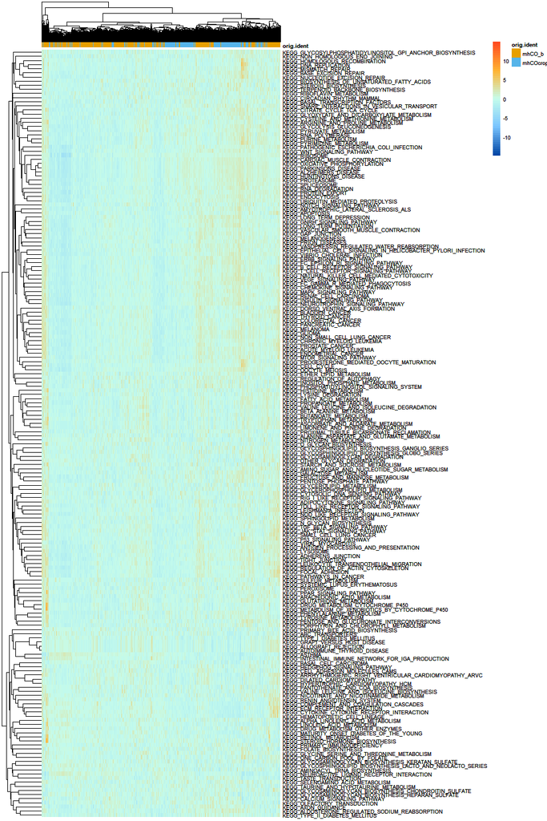

```r
dittoHeatmap(mhCO.combined, genes = NULL, metas = names(ES.mhCO),
             annot.by = "orig.ident",
             fontsize = 7,
             cluster_cols = TRUE,
             heatmap.colors = colors(50))
```

We better produce a heatmap with select gene sets by providing specific names to the metas parameter. For example, we can isolate gene sets involved in Alzheimer’s and Parkinson’s disease.

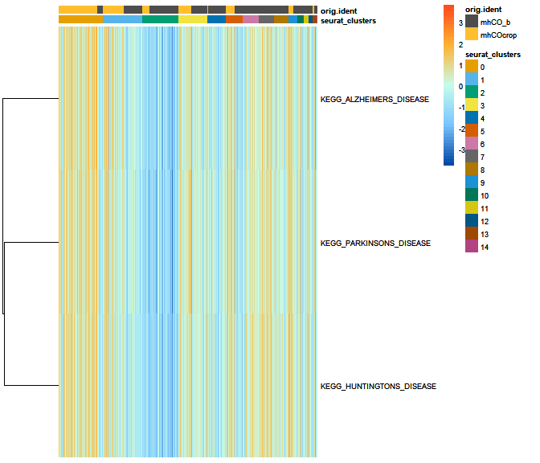

```r
dittoHeatmap(mhCO.combined, genes = NULL,
             metas = c("KEGG_ALZHEIMERS_DISEASE", "KEGG_PARKINSONS_DISEASE",
                       "KEGG_HUNTINGTONS_DISEASE"),
             annot.by = c("seurat_clusters","orig.ident"),
             fontsize = 7,
             heatmap.colors = colors(50))
```

Violin Plots Another way to visualize a subset of gene set enrichment would be to graph the distribution of enrichment using violin, jitter, boxplot, or ridgeplots. We can also compare between categorical variables using the group.by parameter.

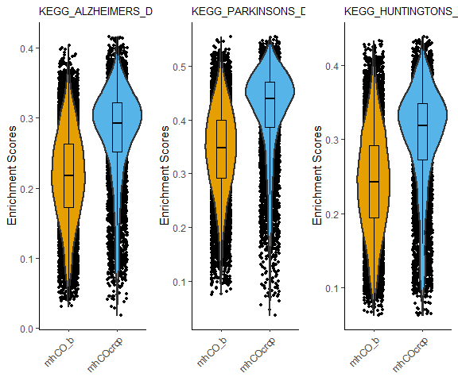

```r
multi_dittoPlot(mhCO.combined, vars = c("KEGG_ALZHEIMERS_DISEASE", "KEGG_PARKINSONS_DISEASE",
                       "KEGG_HUNTINGTONS_DISEASE"),
                group.by = c("orig.ident"), plots = c("jitter", "vlnplot", "boxplot"),
                ylab = "Enrichment Scores",
                theme = theme_classic() + theme(plot.title = element_text(size = 10)))
```

LTD; LTP

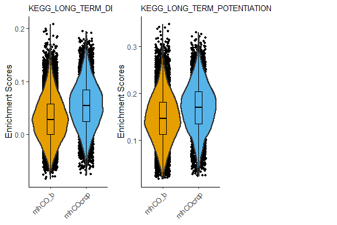

```r
multi_dittoPlot(mhCO.combined, vars = c("KEGG_LONG_TERM_DEPRESSION", "KEGG_LONG_TERM_POTENTIATION"),
                group.by = c("orig.ident"), plots = c("jitter", "vlnplot", "boxplot"),
                ylab = "Enrichment Scores",
                theme = theme_classic() + theme(plot.title = element_text(size = 10)))
```

Another interesting point concerns the same analysis performed on different cell clusters.

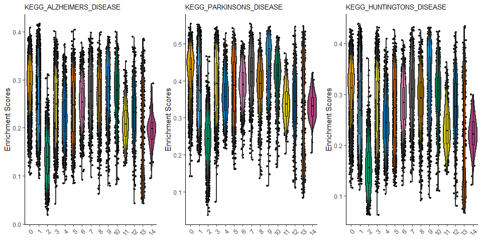

```r
multi_dittoPlot(mhCO.combined, vars = c("KEGG_ALZHEIMERS_DISEASE", "KEGG_PARKINSONS_DISEASE",
                                       "KEGG_HUNTINGTONS_DISEASE"),
                group.by = c("seurat_clusters"), plots = c("jitter", "vlnplot", "boxplot"),
                ylab = "Enrichment Scores",
                theme = theme_classic() + theme(plot.title = element_text(size = 10)))
```

- Hex Density Enrichment Plots

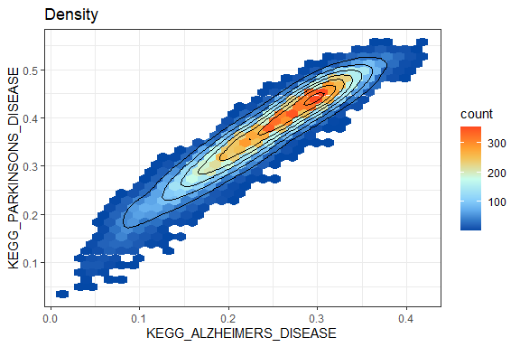

```r
dittoScatterHex(mhCO.combined, x.var = "KEGG_ALZHEIMERS_DISEASE",
                y.var = "KEGG_PARKINSONS_DISEASE",
                do.contour = TRUE) +
  scale_fill_gradientn(colors = colors(11))
```

Let’s assess the distributions in the different samples.

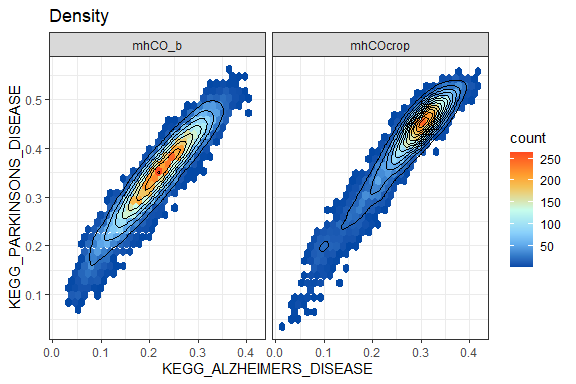

```r
dittoScatterHex(mhCO.combined, x.var = "KEGG_ALZHEIMERS_DISEASE",
                y.var = "KEGG_PARKINSONS_DISEASE",
                do.contour = TRUE,
                split.by = "orig.ident")  +
scale_fill_gradientn(colors = colors(11))
```

It seems like that, having little microglia-related cells, we recovered the Alzherimer’s phenotype present in hCO treated with Aβ.

```r
ES2 <- data.frame(mhCO.combined[[]], Idents(mhCO.combined))
colnames(ES2)[ncol(ES2)] <- "cluster"
```

- Ridge Plots The next step we will do is to evaluate Enrichment score per each cell cluster, depicted in the following ridge plots.

First we will assess Alzheimer’s disease ES’s:

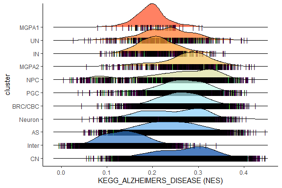

```r
ridgeEnrichment(ES2, gene.set = "KEGG_ALZHEIMERS_DISEASE", group = "cluster", add.rug = TRUE)
```

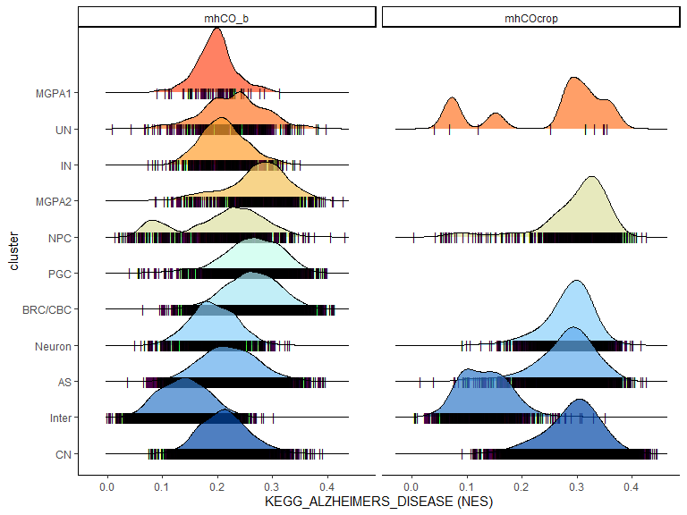

```r
ridgeEnrichment(ES2, gene.set = "KEGG_ALZHEIMERS_DISEASE", group = "cluster",
                facet = "orig.ident", add.rug = TRUE)
```

and finally, apoptosis levels:

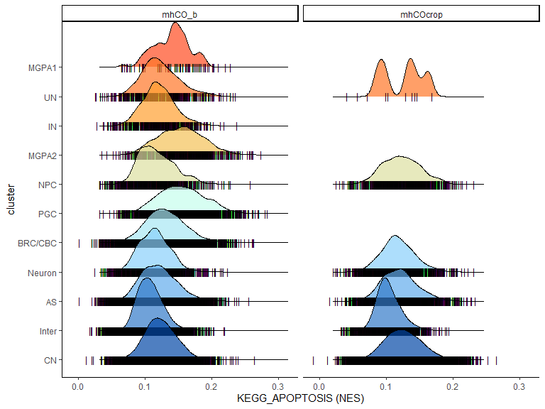

```r
ridgeEnrichment(ES2, gene.set = "KEGG_APOPTOSIS", group = "cluster",
                facet = "orig.ident", add.rug = TRUE)
```

Split Violin Plots

[figure not shown]

```r
splitEnrichment(ES2, split = "orig.ident", gene.set = "KEGG_ALZHEIMERS_DISEASE")
```

### Expanded Analysis

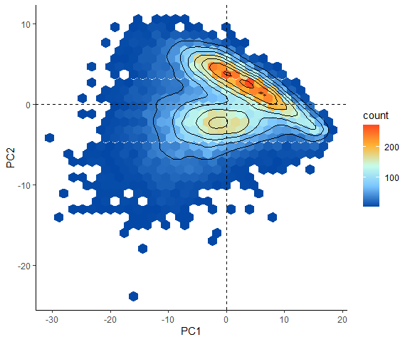

```r
PCA <- performPCA(enriched = ES2, groups = c("orig.ident", "cluster"))
pcaEnrichment(PCA, PCx = "PC1", PCy = "PC2", contours = TRUE)
```

We can also look at the pcaEnrichment() output separated by categorical factors using the facet parameter, for example using the cluster assignment.

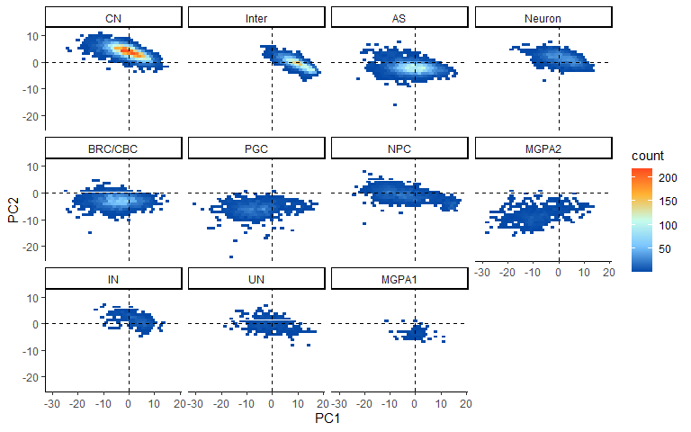

```r
pcaEnrichment(PCA, PCx = "PC1", PCy = "PC2", contours = FALSE, facet = "cluster")
```

We can more closely examine the construction of the PCA by looking at the contribution of each gene set to the respective principal component using masterPCAPlot() with the same input as above with the pcaEnrichment(). We can also control the number of gene sets plotted with top.contribution.

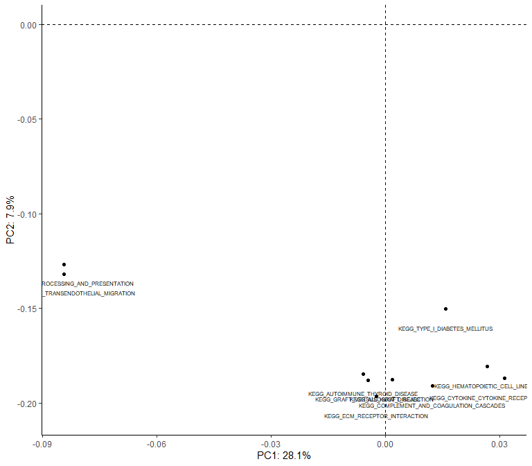

```r
masterPCAPlot(ES2, PCx = "PC1", PCy = "PC2", top.contribution = 10)
```

### Signficance

We can also look for significant differences using linear modeling from the limma package, Welch’s T test or one-way ANOVA using getSignificance().

```r
output <- getSignificance(ES2, group = "orig.ident", fit = "T.test")
head(output, 20)
```

```
#>                                                           T_statistic
#> KEGG_ABC_TRANSPORTERS                                       35.756934
#> KEGG_ACUTE_MYELOID_LEUKEMIA                                  7.690609
#> KEGG_ADHERENS_JUNCTION                                      27.162832
#> KEGG_ADIPOCYTOKINE_SIGNALING_PATHWAY                        33.470630
#> KEGG_ALANINE_ASPARTATE_AND_GLUTAMATE_METABOLISM             28.018188
#> KEGG_ALDOSTERONE_REGULATED_SODIUM_REABSORPTION             -37.337978
#> KEGG_ALLOGRAFT_REJECTION                                    36.355416
#> KEGG_ALPHA_LINOLENIC_ACID_METABOLISM                         1.158989
#> KEGG_ALZHEIMERS_DISEASE                                    -66.364077
#> KEGG_AMINO_SUGAR_AND_NUCLEOTIDE_SUGAR_METABOLISM            -7.180288
#> KEGG_AMINOACYL_TRNA_BIOSYNTHESIS                            -3.968830
#> KEGG_AMYOTROPHIC_LATERAL_SCLEROSIS_ALS                     -33.429958
#> KEGG_ANTIGEN_PROCESSING_AND_PRESENTATION                    27.374533
#> KEGG_APOPTOSIS                                               7.212001
#> KEGG_ARACHIDONIC_ACID_METABOLISM                             0.761787
#> KEGG_ARGININE_AND_PROLINE_METABOLISM                       -16.297515
#> KEGG_ARRHYTHMOGENIC_RIGHT_VENTRICULAR_CARDIOMYOPATHY_ARVC   72.418267
#> KEGG_ASCORBATE_AND_ALDARATE_METABOLISM                      13.165408
#> KEGG_ASTHMA                                                 35.537484
#> KEGG_AUTOIMMUNE_THYROID_DISEASE                             33.556131
#>                                                                  CI_low
#> KEGG_ABC_TRANSPORTERS                                      0.0133801559
#> KEGG_ACUTE_MYELOID_LEUKEMIA                                0.0033689178
#> KEGG_ADHERENS_JUNCTION                                     0.0190160226
#> KEGG_ADIPOCYTOKINE_SIGNALING_PATHWAY                       0.0135278609
#> KEGG_ALANINE_ASPARTATE_AND_GLUTAMATE_METABOLISM            0.0137296809
#> KEGG_ALDOSTERONE_REGULATED_SODIUM_REABSORPTION            -0.0250571580
#> KEGG_ALLOGRAFT_REJECTION                                   0.0150614837
#> KEGG_ALPHA_LINOLENIC_ACID_METABOLISM                      -0.0004621010
#> KEGG_ALZHEIMERS_DISEASE                                   -0.0637238780
#> KEGG_AMINO_SUGAR_AND_NUCLEOTIDE_SUGAR_METABOLISM          -0.0052887902
#> KEGG_AMINOACYL_TRNA_BIOSYNTHESIS                          -0.0033055754
#> KEGG_AMYOTROPHIC_LATERAL_SCLEROSIS_ALS                    -0.0225458792
#> KEGG_ANTIGEN_PROCESSING_AND_PRESENTATION                   0.0165282420
#> KEGG_APOPTOSIS                                             0.0020796322
#> KEGG_ARACHIDONIC_ACID_METABOLISM                          -0.0004757764
#> KEGG_ARGININE_AND_PROLINE_METABOLISM                      -0.0105134338
#> KEGG_ARRHYTHMOGENIC_RIGHT_VENTRICULAR_CARDIOMYOPATHY_ARVC  0.0267029488
#> KEGG_ASCORBATE_AND_ALDARATE_METABOLISM                     0.0107806321
```

[output cut: 92 more lines]

```
#> KEGG_ALDOSTERONE_REGULATED_SODIUM_REABSORPTION            1.603290e-289
#> KEGG_ALLOGRAFT_REJECTION                                  3.168934e-276
#> KEGG_ALPHA_LINOLENIC_ACID_METABOLISM                       1.000000e+00
#> KEGG_ALZHEIMERS_DISEASE                                    0.000000e+00
#> KEGG_AMINO_SUGAR_AND_NUCLEOTIDE_SUGAR_METABOLISM           2.464919e-11
#> KEGG_AMINOACYL_TRNA_BIOSYNTHESIS                           1.669143e-03
#> KEGG_AMYOTROPHIC_LATERAL_SCLEROSIS_ALS                    1.662836e-234
#> KEGG_ANTIGEN_PROCESSING_AND_PRESENTATION                  1.110993e-159
#> KEGG_APOPTOSIS                                             2.007923e-11
#> KEGG_ARACHIDONIC_ACID_METABOLISM                           1.000000e+00
#> KEGG_ARGININE_AND_PROLINE_METABOLISM                       1.972921e-57
#> KEGG_ARRHYTHMOGENIC_RIGHT_VENTRICULAR_CARDIOMYOPATHY_ARVC  0.000000e+00
#> KEGG_ASCORBATE_AND_ALDARATE_METABOLISM                     1.345986e-37
#> KEGG_ASTHMA                                               5.375792e-265
#> KEGG_AUTOIMMUNE_THYROID_DISEASE                           8.432702e-237
```